# Trabajo Práctico 3

Gazze - Irisarri - Landa

2024-05-23

# Introducción

Sumergirse en el mundo de la estadística puede llevarnos a lugares inesperados, desafiando nuestras percepciones y llevándonos a explorar terrenos desconocidos. En esta ocasión, nos sumergimos en un caso peculiar que fusiona el rigor analítico con el misterio de una escena del crimen.

Nuestra historia se centra en Guido, un apasionado estudiante de estadística cuyo amor por la resolución de enigmas lo llevó desde las aulas universitarias hasta las intrigantes calles de Córdoba.

Sin embargo, la emoción de seguir su vocación se ve eclipsada por un oscuro suceso. En una madrugada envuelta en sombras, la unidad de trabajo de Guido es convocada de manera urgente para investigar un crimen recién perpetrado en Salsipuedes.

En medio del desorden, muebles destrozados, utensilios de cocina esparcidos y, en el centro de todo, el cuerpo inerte de Sergio Contreras, bañado en un charco de sangre. Ante esta escena, Guido se enfrenta a un desafío crucial: determinar la hora en que se produjo la muerte.

Como estudiantes de estadística, nos embarcamos en este enigma con la tarea de ayudar a Guido a determinar la hora exacta de la muerte de Sergio Contreras y, así, acercarnos un paso más hacia la resolución de este misterio.

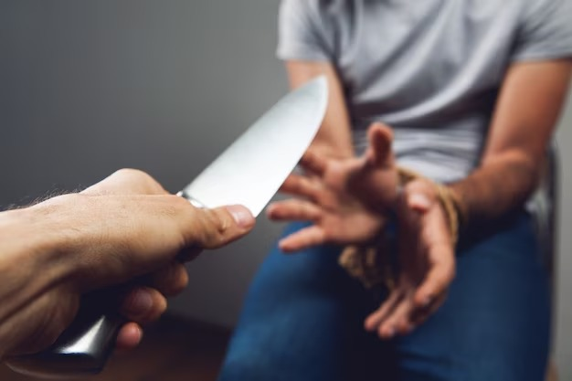

Imagen 1: Sergio minutos antes de su muerte

# Objetivos

El objetivo principal de este informe es utilizar métodos estadísticos con enfoque bayesiano para estimar con precisión la hora de muerte de Sergio Contreras. A través del estudio de la temperatura corporal postmortem y la aplicación de modelos lineales, buscaremos proporcionar una estimación confiable del momento en que ocurrió el deceso. Además, nuestro objetivo secundario es presentar los resultados de manera clara y concisa, demostrando un dominio completo del contenido y garantizando así la obtención de una calificación sobresaliente (10😉) en la evaluación del informe.

# Metodología

A través del análisis de la temperatura corporal, ecuaciones diferenciales y conceptos matemáticos podremos descifrar el objetivo planteado.

Sabemos que la temperatura del cuerpo de Sergio satisface la siguiente ley:
$$\frac{dT(t)}{dt}=r[T_{amb}-T(t)]$$
donde:

- $T_{amb}$ es la temperatura ambiente (un valor fijo y conocido),
- $r$ es una constante y
- $T(t)$ es la función (en principio desconocida) que describe la temperatura del cuerpo en función del tiempo.

Se puede demostrar que una función que satisface esa ecuación es $T(t)=T_{amb}+(T_i-T_{amb})e^{-rt}$

$$\frac{dT(t)}{dt}=\frac{d}{dt}(T(t)=T_{amb}+(T_i-T_{amb})e^{-rt})=$$
$$=(T_i-T_{amb})e^{-rt}(-r)=-r(T_i-T_{amb})e^{-rt}=$$
$$=-r(T_i-T_{amb})e^{-rt}+rT_{amb}-rT_{amb}=$$
$$=-r[(T_i-T_{amb})e^{-rt}+T_{amb}]+rT_{amb}=$$

$$=-r[T(t)-T_{amb}]=r[T_{amb}-T(t)]$$
donde:

- $T_i$ la temperatura a la que está inicialmente el cuerpo de Sergio.

# Desarrollo

Para averiguar que indica la constante r, y que valores son coherentes, graficamos la función anterior para distintos valores de $r$, sabiendo que la temperatura del ambiente es $23°C$ y la temperatura al momento de la muerte de Sergio es $37°C$.

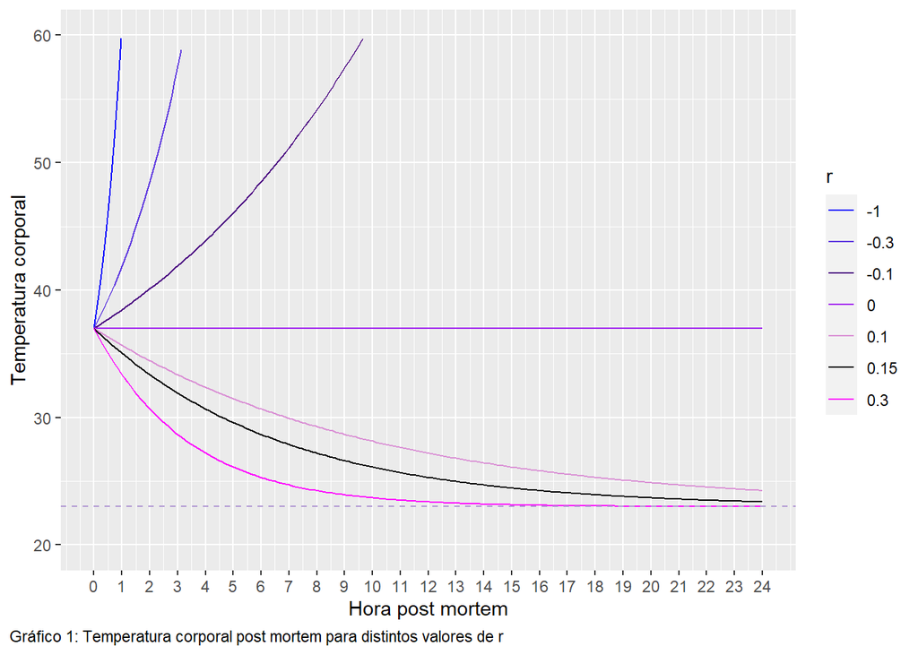

Sabemos que la temperatura corporal eventualmente alcanza el equilibrio térmico con el ambiente, por lo que no desciende más de $23°C$. Además, al observar los gráficos, se puede deducir que $r$ representa la rapidez con la que la temperatura corporal disminuye hasta igualarse con la del entorno. Por este motivo, el valor de $r$ no puede ser negativo, ya que en estos casos la temperatura aumenta y no es coherente en este problema.

En términos generales, los cadáveres pierden $2 °C$ de temperatura durante la primera hora después del deceso. Luego pierde alrededor de $1.5 °C$ por hora durante las siguientes 12 horas y, en las horas posteriores, la temperatura desacelera su descenso hasta llegar a la temperatura ambiente, aproximadamente 24 hs luego de la muerte.

Por lo tanto, llegamos a la conclusión de que $0.15$ es un valor lógico para $r$, ya que en las primer hora vemos una disminución de $1.95°C$ en la temperatura corporal, luego, para las siguientes 12 horas la temperatura descendera en razón de entre $1°C$ y $1.5°C$ por hora. Posteriormente la temperatura seguirá descendiendo de manera más lenta hasta llegar a la temperatura ambiente aproximadamente 24hs despues de la muerte.

Para responder nuestro objetivo tendremos en cuenta las siguientes consideraciones: En lugar de considerar la temperatura del cuerpo, se considerará la diferencia entre la temperatura del cuerpo y la temperatura ambiente $(T-T_{amb})$. Además, se llamará $T_{diff}$ a la diferencia entre la temperatura inicial del cuerpo y la temperatura ambiente $(T_i-T_{amb})$.

$$T(t)-T_{amb}=T_{diff}e^{-rt}$$

Para linealizar la ecuación aplicamos logaritmo natural a nuestra nueva variables $T(t)-T_{amb}$
$$ln(T(t)-T_{amb})=ln(T_{diff})-rt$$
Mostramos esto graficamente utilizando $r = 0.15$:

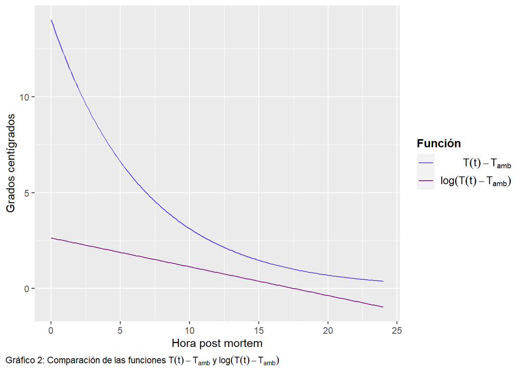

El intercepto de la función logaritmo de $T(t)-T_{amb}$ es $ln(T_{diff})=2.639$ , lo que indica que la diferencia entre la temperatura corporal y la temperatura ambiente en el momento de la muerte es $e^{2.639}°C=14°C$. La pendiente es $-r=-0.15$, esto significa que a medida que aumenta una hora, el valor esperado del logaritmo de la diferencia entre la temperatura corporal y la temperatura ambiente disminuye en $0.15°C$.

Para resolver nuestro objetivo proponemos ajustar un modelo lineal normal, en el que tomaremos como variable explicativa las horas que pasaron desde la muerte. A continuación se presentan los hechos transcurridos en la noche del fallecimiento de Sergio para ingresar estos datos en el modelo.

[figure not shown]

Para deducir un prior para el intercepto suponemos que la verdadera función que describe el descenso de temperatura post mortem ( *algor mortis* ) es aquella que presentamos con $r=0.15$. Luego, tomamos las mediciones de las 6:45 am y 8:15 am, las proyectamos a traves de nuestra función y obsevarmos cuántas horas transcurrieron desde la muerte.

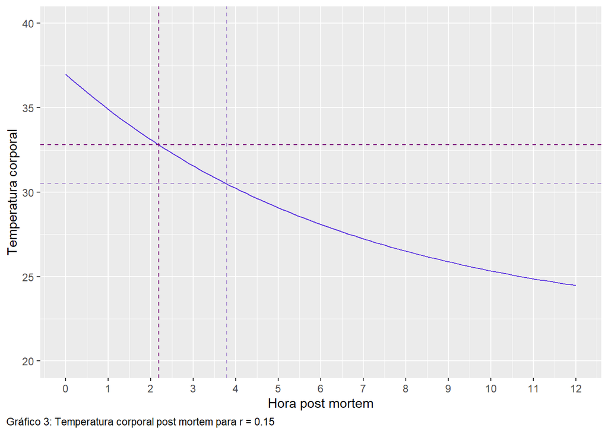

En este razonamieto no tenemos en cuenta la temperatura constatada a las 13:30 hs ya que suponemos que, al llegar a la morgue (9:55 am), el cuerpo fue resguardado en cámaras frigoríficas hasta la hora de la autopsia , por lo que su temperatura dismunuyó más rápido que el comportamiento natural.

Planteamos el modelo:

$Y_i| \beta_0, \beta_1, \sigma \sim N (\mu_i, \sigma)$

$\mu_i = \beta_0 + \beta_1t$

$\sigma \sim N^+ (\theta_2=1)$

Donde:

- $Y_i=log(T(t)-T_{amb})$
- $\beta_0$: es el intercepto de la recta
- $\beta_1$: es la pendiente de la recta
- $\sigma$: desvío estándar de $Y_i$
- $t$: horas transcurridas desde las 4:30 am (hora aproximada ‘a priori’ de muerte).

Hacemos el supuesto de que los parámetros son independientes, por lo que podemos postular un prior marginal para cada uno. Además pensamos que la muerte de Sergio ocurrió en un horario cercano al ya mencionado (4:30am), y tendremos en cuenta esto para deducir nuestras distribuciones a priori.

Para definir el prior de $\beta_1$ asumimos que la pendiente no puede ser positiva, ya que la diferencia entre la temperatura de un cuerpo sin vida y la temperatura ambiente irá disminuyendo conforme pasen las horas (a menos que lo esten cremando🤭). Por lo tanto, asumimos un prior de $\beta_1$ con distribución Normal con media $\mu = -0.15$ y desvío $\theta_1 = 0.04$.

Por último como $\sigma$ no puede tomar valores negativos, decidimos postular una distribución Media Normal Positiva con desvío $\theta_2 = 1$ porque pensamos que el logaritmo de las diferencias de temperaturas pueden estar como mucho entre 0 y 3.

Mostramos graficamente los prior mencionados:

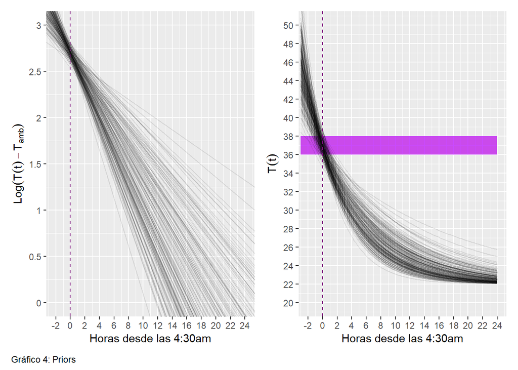

Basandonos en los priors mencionados y el supuesto de parámetros independientes, podemos obtener la distribución predictiva a priori a través de muestras. Para realizar esto se toman valores puntuales de $t$.

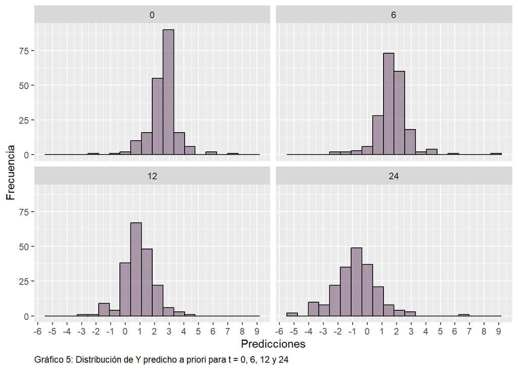

| Hs post mortem | Media de Y predicho | Temperatura predicha promedio |
| --- | --- | --- |
| 0 | 2.573 | 35.099 |
| 6 | 1.711 | 27.537 |
| 12 | 0.891 | 24.438 |
| 24 | -0.778 | 22.459 |

Tabla 1: temperatura corporal predicha según tiempo

Utilizando la estadística bayesiana, podemos actualizar nuestras creencias a priori a medida que obtengamos nueva evidencia. Aplicaremos modelos lineales normales bayesianos para estimar la hora de muerte de Sergio Contreras. Estos modelos nos ayudarán a relacionar la temperatura corporal con el tiempo transcurrido desde la muerte. Utilizamos RStan para ajustar el modelo:

```
##
##   data {
##     int<lower=0> N;
##     vector[N] y;
##     vector[N] x;
##   }
##
##   // Definimos los parámetros, de qué tipo son, y sus cotas
##   parameters {
##     real beta0;
##     real beta1;
##     real<lower=0> sigma;
##   }
##
##   // Pasamos el modelo
##   model {
##     beta0 ~ normal(2.7, 0.1);
##     beta1 ~ normal(-0.15, 0.04);
##     sigma ~ normal(0, 1);
##     y ~ normal(beta0 + beta1 * x, sigma);
##   }
```

Para la primer parte de esta sección tendremos en cuenta la información recolectada hasta las 7 de la mañana. A través de esta, calcularemos nuestros posteriors y mediante el uso de ellos, obtenemos una estimación de la hora aproximada en la que Sergio abandonó la vida.

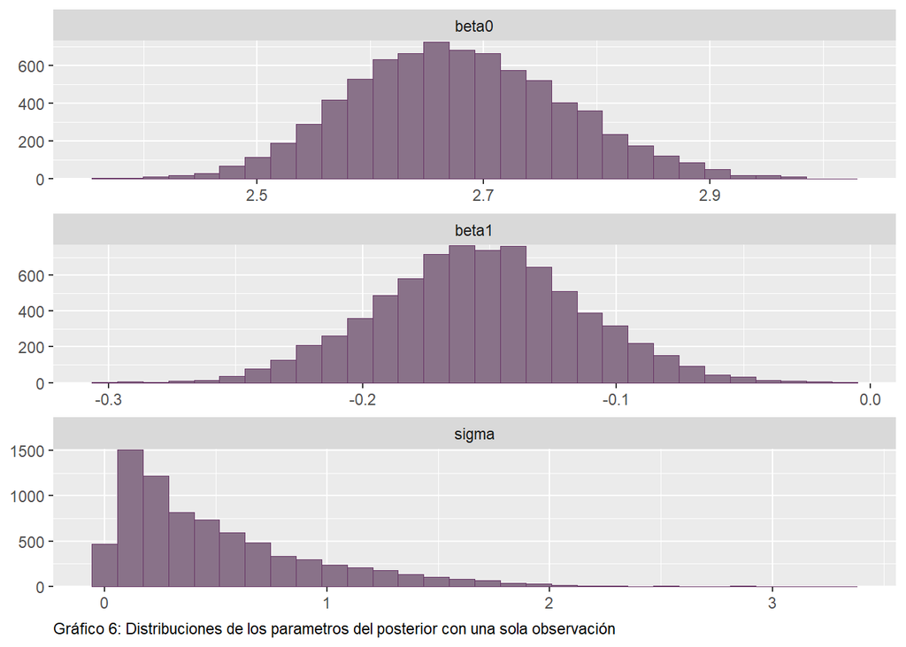

En el gráfico 6, vemos que las distribuciones a posteriori de los parámetros se modifican muy levemente en relación a nuestras creencias a priori, esto era de esperarse ya que solo tenemos un dato. A continuación observamos las rectas estimadas a posteriori para la $log(T(t)-T_{amb})$ y para $T(t)$.

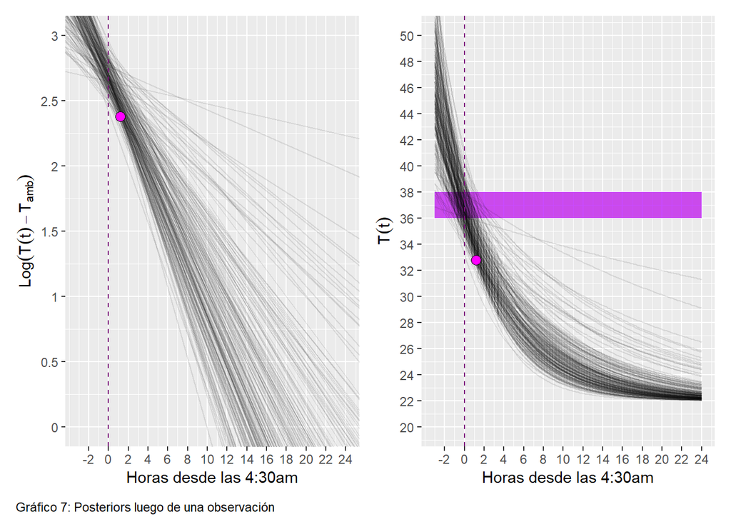

Vemos en el gráfico 7 que el intercepto decrece levemente en promedio, en comparación con el gráfico 4 y que el punto observado se ajusta a las rectas. Tambien vemos aquí que la temperatura corporal se encuentra entre 36 y 38 grados para valores de tiempo menores a cero. A continuación vemos esto con más profundidad:

Vamos a calcular la distribución a posteriori de $t$ para la temperatura corporal de 37 grado. Sabiendo que $ln(T(t=0)-T_{amb})=\beta_0$ y $-r=\beta_1$
$$T(t)=(T(t=0)-T_{amb})e^{-rt}+T_{amb}
=>$$
$$=>37°C=e^{\beta_0}e^{\beta_1.t}+22°C=>$$
$$=>37°-22°=e^{\beta_0+\beta_1.t}=>$$
$$=>ln(15°)={\beta_0+\beta_1.t}=>$$
$$=>\frac{ln(15°)-\beta_0}{\beta_1}={t}$$
Y así conseguimos la distribución del tiempo $t$ cuando la temperatura es $37°C$.

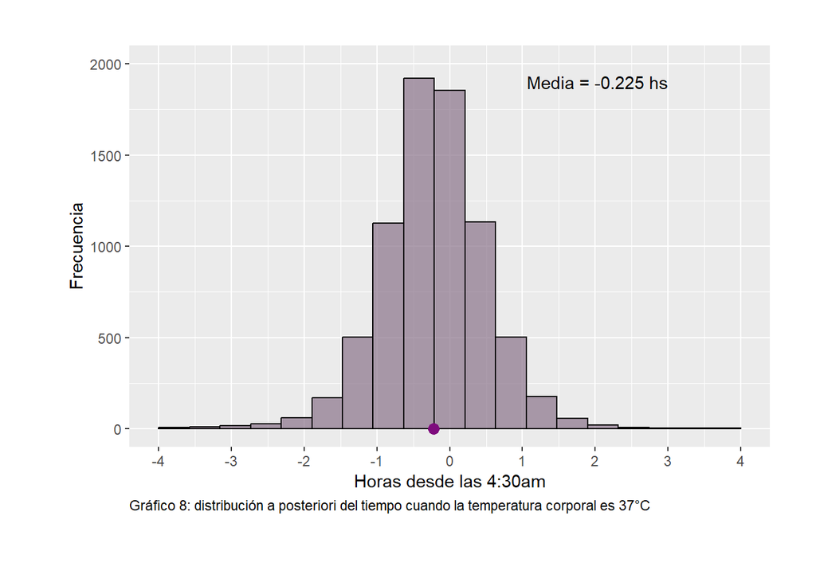

Observamos la distribución de los tiempos a posteriori cuando la temperatura corporal de Sergio es $37°C$. Podemos mencionar que la hora de muerte estimada de Sergio entre -1.67 horas antes de las 4:30am y 1.18 horas después, es decir que el verdadero horario de muerte estará entre las 2:50am y 5:40am. El valor medio de esta distribución es -0.225, lo que indica que el horario promedio de muerte fue a las 4:17am.

A continuación presentamos las **medidas diagnóstico** para corroborar que el proceso realizado es adecuado, es decir, analizar como se comportan las cadenas obtenidas a través de MCMC.

*Medidas numéricas:*

| Parámetro | Neff | Rhat |
| --- | --- | --- |
| $\beta_0$ | 2956 | 1.00 |
| $\beta_1$ | 6853 | 1.00 |
| $\sigma$ | 714 | 1.01 |

Tabla 2: medidas diagnóstico

Observamos que los valores del $\hat{R}$ para los distintos parámetros presentan valores que practicamente no difieren de 1, lo que nos dice que las distintas cadenas convergen. Mientras que analizando el $\ N_{eff}$= **número efectivo de muestras** obtenemos a cuantas muestras independientes equivalen nuestras 7600 muestras, en todos los parámetros contamos con al menos 700 muestras independientes por lo que podemos concluir que serán una buena representación del posterior.

*Trace plots:*

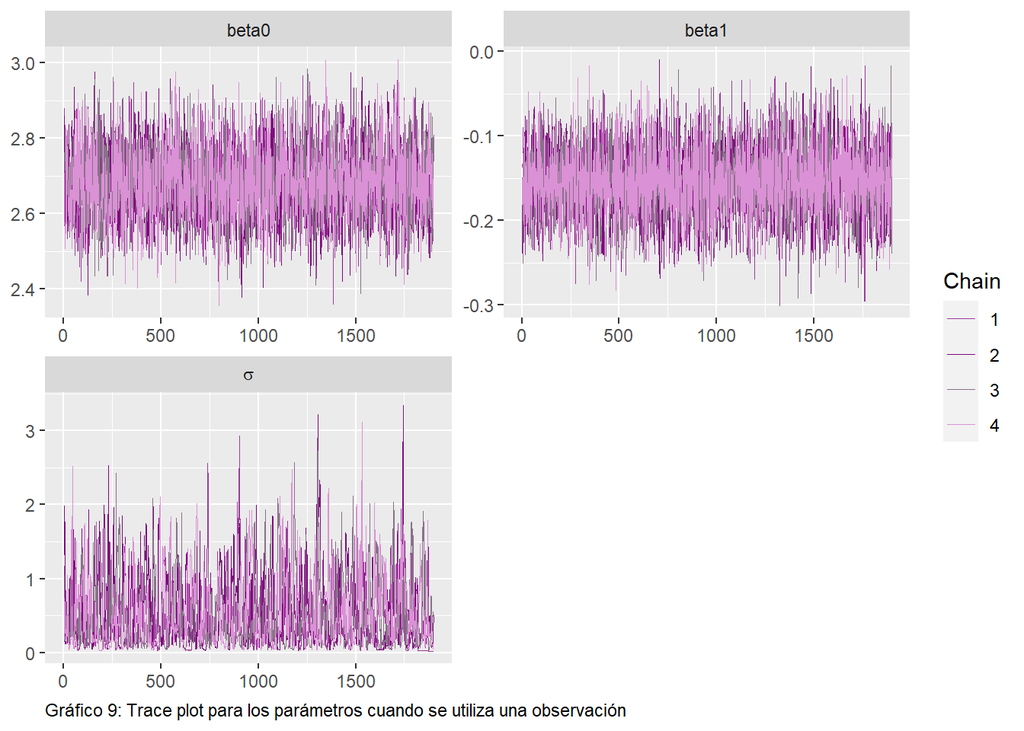

Se observa un patrón de ruido blanco a través de las muestras, esto es un buen indicio del comportamiento de nuestro algoritmo de muestreo.

*Densidad de los parámtros para las distintas cadenas:*

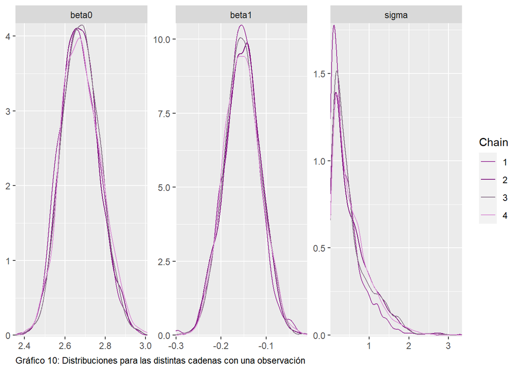

Observamos que para cada uno de nuestros parámetros, las densidades calculadas con distintas cadenas no presentan grandes diferencias, lo cual nos llevaría a pensar que estas convergieron y que el proceso de muestreo pareciera ser bueno.

Continuamos nuestro análisis incorporando la información obtenida hasta las 10am, es decir, contaremos con una nueva observación. Procedemos a obtener los nuevos posteriors y sus respectivas muestras, y mediante ellos realizamos la estimación de la hora de muerte de Sergio.

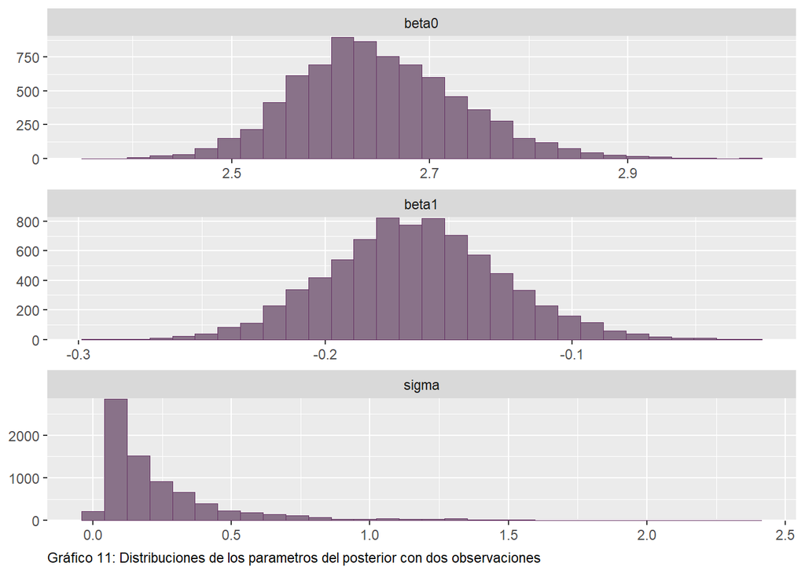

En el gráfico 11, vemos nuevamente que las distribuciones a posteriori de los parámetros se modifican levemente en relación a nuestras creencias a priori. Vemos una tendencia decreciente tanto en $\beta_0$ como en $\beta_1$.

Observamos las distintas rectas para los valores de los posterior y sus respetivos comportamientos de la temperatura corporal luego de la segunda observación.

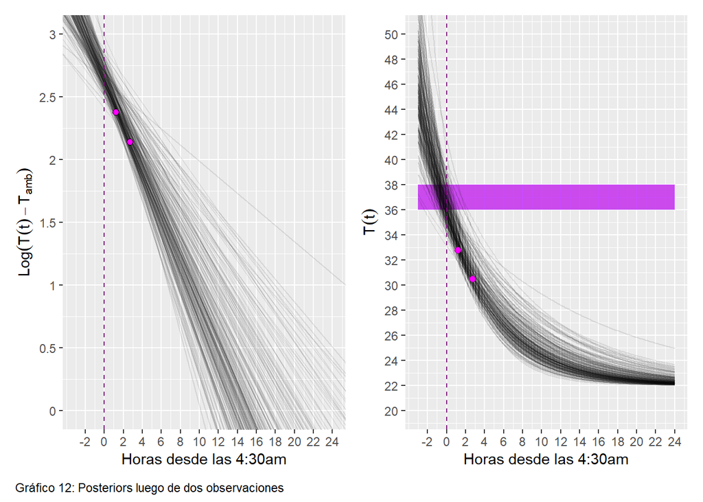

En primer lugar podemos mencionar que las rectas se ajustan cada vez más a los datos, aqui notamos la influencia del *likelihood*. Tambien podemos ver que, cuando la temperatura corporal de Sergio se encantraba entre $36°C$ y $38°C$, los valores de $t$ suelen ser menores a $0$, lo que nos da indicio de que la muerte sucedio antes de las 4:30 am.

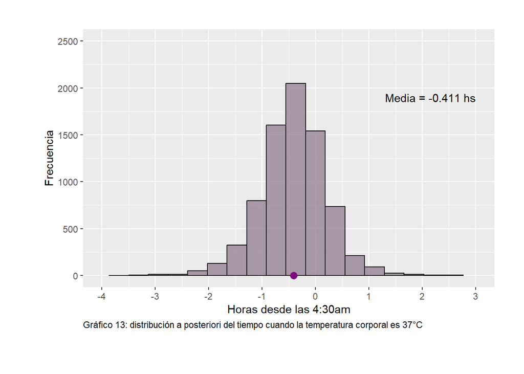

Observamos la distribución de los tiempos a posteriori cuando la temperatura corporal de Sergio es $37°C$. Podemos mencionar que la hora de muerte estimada de Sergio entre -1.7 horas antes de las 4:30am y 0.77 horas después, es decir que el verdadero horario de muerte estará entre las 2:48am y 5:16am. Vemos que el intervalo horario tiene menor amplitud que cuando teniamos una sola observación. Además, el valor medio de esta distribución es -0.411, lo que indica que el horario promedio de muerte fue a las 4:05am.

A continuación presentamos las **medidas diagnóstico** para corroborar que el proceso realizado es adecuado, es decir, analizar como se comportan las cadenas obtenidas a través de MCMC.

*Medidas numéricas:*

| Parámetro | Neff | Rhat |
| --- | --- | --- |
| $\beta_0$ | 1001 | 1.02 |
| $\beta_1$ | 3055 | 1.00 |
| $\sigma$ | 273 | 1.03 |

Tabla 3: medidas diagnóstico

Vemos que los valores del $\hat{R}$, aunque distintos de 1, siguen cumpliendo la condición de ser menores a 1.1 para todos los parámetros, lo cual es un indicio de convergencia (Gelman & Hill, 2006). Analizando el $\ N_{eff}$ obtenemos a cuantas muestras independientes equivalen nuestras 7600 muestras, aunque vemos una disminución de las mismas comparado con la muestra anterior, en todos los parámetros contamos con al menos 250 muestras independientes por lo que podemos concluir que serán una buena representación del posterior.

*Trace plots:*

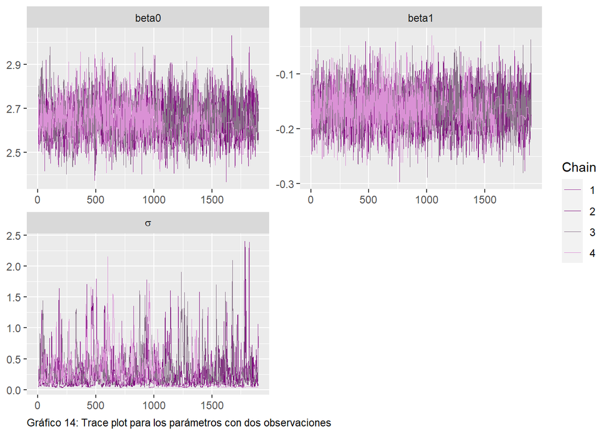

Nuevamente observamos un patrón de ruido blanco a través de las muestras, lo que indica que el comportamiento de nuestro algoritmo es bueno.

*Densidad de los parámtros para las distintas cadenas:*

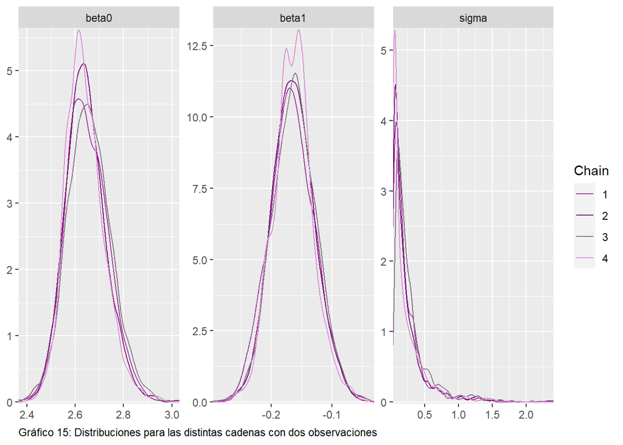

Se observan pequeñas disimilitudes en las cadenas, pero no parece ser algo por lo que debamos preocuparnos.

Finalmente trabajaremos con toda la información disponible, es decir, contaremos con las tres observaciones de la temperatura corporal post mortem de Sergio. Procedemos a obtener los nuevos posteriors y sus respectivas muestras, y realizamos nuevas estimaciones de la hora de muerte de Sergio.

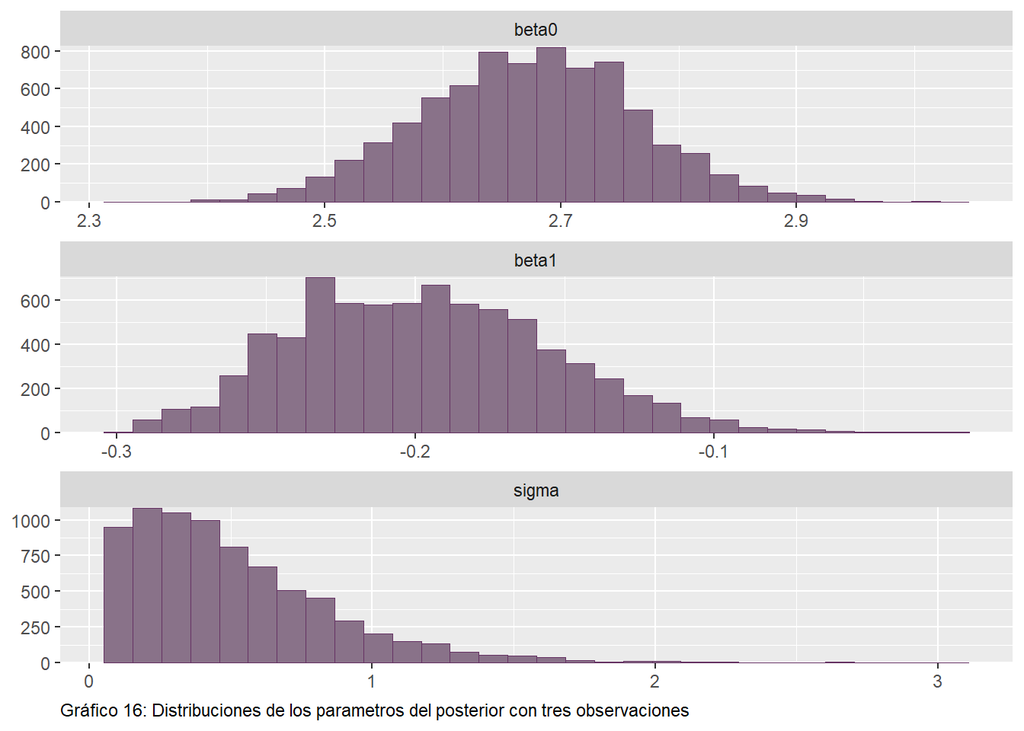

Se observan las distribuciones a posterior luego de considerar toda la información disponible, en el gráfico 16 vemos que el parametro $\beta_1$ parece ser el mayormente influenciado por la ultima observacion ya que decrece y se centra en $-0.2$, lo que indica que la temperatura disminuye a mayor velocidad de lo planteado.

Observamos las distintas rectas para los valores de los posterior y sus respetivos comportamientos luego de considerar la tercer observación.

[figure not shown]

Sabemos que antes de tomarse esta tercer medición de temperatura (a las 13:30 hs) el cuerpo de Sergio fue trasladado en una bolsa de obito y luego resguardado en la morgue desde las 9:55 am hasta la hora de la autopsia. Tambien sabemos que cada morgue cuenta con salas o cuartos destinados a la recepción y almacenamiento de los cuerpos, cada una de ellas debe estar correctamente refrigerada. Hete aqui el motivo por el cual el cuerpo de Sergio presenta una temperatura menor a la esperada.

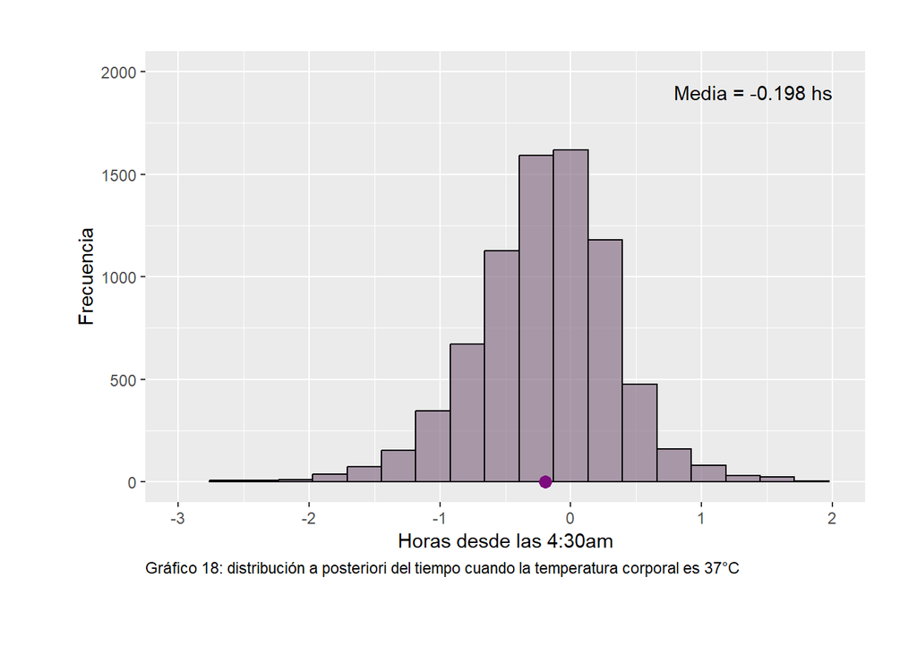

Por ultima vez presentamos la distribución de los tiempos a posteriori cuando la temperatura corporal de Sergio es $37°C$. La hora de muerte de Sergio se presenta entre -1.31 horas antes de las 4:30am y 0.79 horas después, es decir que el supuesto horario de muerte estará entre las 3:11am y 5:17am y el valor medio de esta distribución es -0.198, lo nos dice que el horario promedio de muerte fue a las 4:18am. Por lo expuesto anteriormente, no creemos que esta sea una representación fidedigna del horario de muerte de Contreras, ya que la temperatura a la que estuvo expuesto entre las 10 am y las 13:30 hs, fue mucho menor a la temperatura ambiente que tuvimos en cuenta a lo largo del informe.

A continuación presentamos las **medidas diagnóstico** para corroborar que el proceso realizado es adecuado, es decir, analizar como se comportan las cadenas obtenidas a través de MCMC.

*Medidas numéricas:*

| Parámetro | Neff | Rhat |
| --- | --- | --- |
| $\beta_0$ | 837 | 1.01 |
| $\beta_1$ | 106 | 1.04 |
| $\sigma$ | 208 | 1.02 |

Tabla 4: medidas diagnóstico

Observamos que los números efectivos de muestras para nuestros parámetros decrecen, lo que nos indica que el procesos no es igual de óptimo que en los casos anteriores, de igual forma obtenemos el equivalente a 100 muestras independientes o más en cada caso. El $\hat{R}$ sigue siendo menor a $1.1$, por lo que se cumplen los criterios de convergencia ya mencionados.

*Trace plots:*

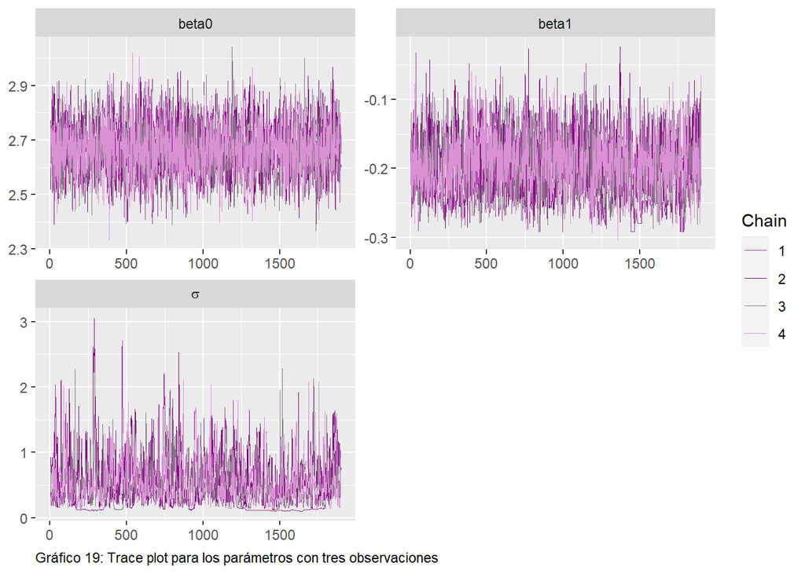

*Densidad de los parámtros para las distintas cadenas:*

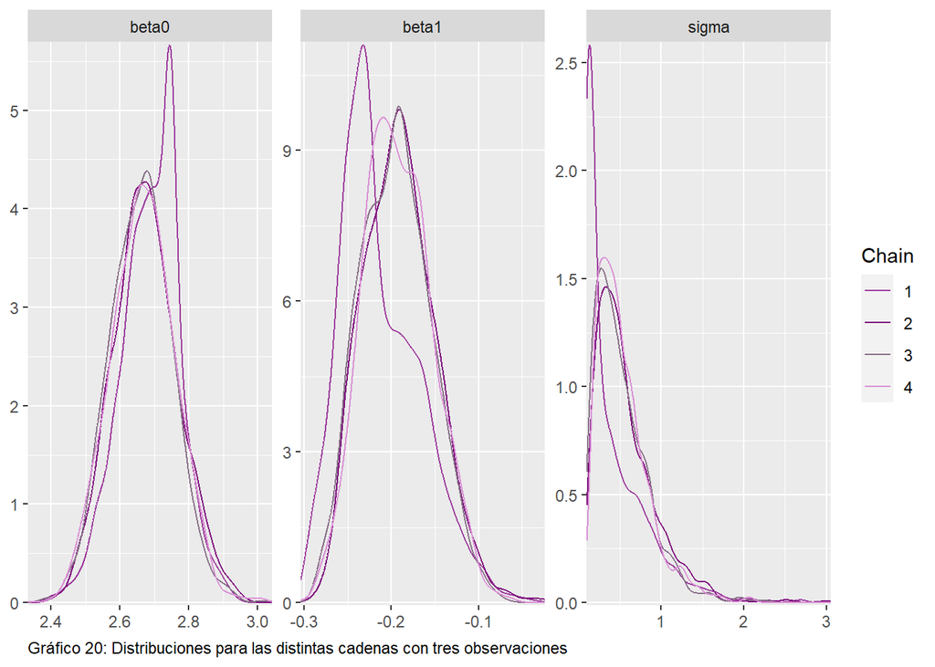

Las distribuciones de los parámetros parecieran diferir levemente para las distintas cadenas, lo cual no representa un problema real para nuestro análisis, más que nada teniendo en cuenta que esta última estimación no será tenida en cuenta por el resultado atípico presentado.

# Conclusiones

En este trabajo, hemos aplicado métodos de estadística bayesiana para estimar la hora de muerte de Sergio Contreras, analizando la evolución de su temperatura corporal post mortem. Para nuestro modelo, establecimos distribuciones a priori informativas para el intercepto y la pendiente de la recta, la cual representa el logaritmo natural de la diferencia de temperatura entre el cuerpo y el ambiente, así como para su desvío estándar. Estas distribuciones a priori fueron necesarias debido a la cantidad limitada de observaciones disponibles y para incorporar nuestro conocimiento previo sobre la tasa de enfriamiento del cuerpo humano y la temperatura corporal típica en vida. Utilizando Rstan, pudimos ajustar y actualizar nuestro modelo lineal bayesiano en función de las observaciones obtenidas. Esto nos permitió incorporar variación en la temperatura corporal y actualizar nuestras creencias a priori con los datos observados.

A partir de las mediciones de temperatura, estimamos que la hora de muerte ocurrió alrededor de las 4:05 am, con un intervalo de credibilidad del 95% que va de 2:48 am a 5:16 am, basándonos en las dos primeras observaciones. La tercera medición mostró una desviación significativa debido al enfriamiento en la morgue, lo que afectó las estimaciones. Por lo que concluimos que los resultados obtenidos en primera instancia nos proporcionaran un reflejo más fiel de la hora real del fallecimiento de Sergio Contreras.

Consideramos la posibilidad de que un factor como la fiebre alta al momento de la muerte pudiera influir en el proceso de enfriamiento del cuerpo, lo que implicaría ajustes en nuestro modelo para reflejar una temperatura inicial más alta a priori ($\beta_0$). Mientras que si supieramos de antemano que Sergio presentaba una enfermedad crónica o debilitante, lo que puede hacer que el cuerpo se enfríe más rápidamente debido a una menor capacidad de retención de calor,modificaríamos la pendiente de nuestro modelo ($\beta_1$). Este análisis demuestra la efectividad de los métodos bayesianos para integrar información previa y posterior, incluso en situaciones con datos limitados.

## Ronda de prensa…

- Periodista: “Buenas tardes, la familia de Sergio quiere respuesta, necesita respuesta. ¿Pueden darnos con certeza el horario de muerte de Contreras?”
- Guido: “Buenas tardes. Desde el equipo de la policía científica de Córdoba, podemos declarar que el día de la fecha, en la localidad de Salsipuedes, ocurrió un lamentable incidente. Tras recibir un llamado de emergencia a las 5:33 hs, la policía se trasladó al lugar y constató la presencia del cuerpo sin vida de Sergio Contreras, masculino, 45 años, en su domicilio. Según nuestras investigaciones y utilizando métodos avanzados de estadística bayesiana, hemos determinado que la muerte de Sergio Contreras ocurrió aproximadamente a las 4:05 am, y estamos muy convencidos que realmente ocurrió entre las 2:48 am y las 5:16 am. La causa de la muerte fue una herida de arma blanca que provocó una hemorragia fatal. Es importante destacar que nuestras estimaciones son producto de un análisis exhaustivo de las mediciones de temperatura corporal, y aunque se consideraron diversas variables y condiciones ambientales, nuestras conclusiones reflejan el momento más probable del deceso del Sr. Contreras. Seguiremos trabajando para esclarecer todos los detalles de este trágico suceso. Gracias…”

# Referencias bibliográficas

*Gelman, A. & Hill, J. (2006). Data Analysis Using Regression and Multilevel-Hierarchical Models. 1st edition.*